# Linking survey to JHS database

Erik Ø. Sørensen

06 januar, 2021

This file generates the Figure about the COVID-19 reminder and outputs a dataset with state-level numbers of confirmed cases in `data/corona_status_March-28.csv`.

# Reading data

Reading data from Ipsos:

```r
wavedate_df <- tribble(~Wavemarker, ~wavedt,
                       4, "2020-3-18",  # Not to be used - No COVID-19 reminder
                       5, "2020-3-24",
                       6, "2020-3-25",
                       7, "2020-3-26",
                       8, "2020-3-27",
                       9, "2020-3-30",
                       10,"2020-3-31",
                       11,"2020-4-1",
                       12,"2020-4-2") %>%
  mutate(wavedt = as.Date(wavedt))

ipsos <- haven::read_dta(here::here("data","processed", "ipsos_mmnyt_processed_release.dta")) %>%
 mutate( state = as.character(haven::as_factor(State_Recoded)),
         solidarity = 10 - prior_self_over_soc,
         inequality_aversion = luck_unfair_agree,
         redistribution = gov_reduce_inequality_agree,
         female = as.numeric(resp_gender==2),
         ) %>% left_join(wavedate_df) %>%
  filter(!is.na(wavedt))
```

I have downloaded the JHS covid-19 database of confirmed cases

```r
confirmed_US <- read_csv(here::here("data", "raw", "time_series_covid19_confirmed_US.csv"))
```

Reshaping the JHS data to a longer format that is easier to work with:

```r
confirmed_long <- confirmed_US %>%
  pivot_longer(`1/22/20`:`5/4/20`, names_to="covid_date", values_to="n_confirmed") %>%
  mutate(cdate = mdy(covid_date)) %>%
  group_by(Province_State, cdate) %>%
  summarize(confirmed = sum(n_confirmed))
```

We want to join by population (state level)

```r
population <- read_csv(url("https://www2.census.gov/programs-surveys/popest/datasets/2010-2019/state/detail/SCPRC-EST2019-18+POP-RES.csv")) %>%
  janitor::clean_names() %>%
  dplyr::select(c("name", "popestimate2019")) %>%
  rename(state = name, pop2019 = popestimate2019) %>%
  filter(state != "United States")
```

We want to compare our data collection period with the Google-searches for relevant terms over time:

```r
google_trends <- readRDS(here::here("data","googletrends.rds"))
```

# Merging outcomes

Restricting the set of regions to the states and DC, not the other territories as wellg

```r
US_covid_outcomes <- confirmed_long
long_data <- US_covid_outcomes %>% rename(state = Province_State) %>%
    right_join(population, by=c("state")) %>%
  mutate( confirmed_by_100_000 = confirmed/pop2019 * 100000) %>%
  filter( state %in% ipsos$state )
```

# Confirmed cases and survey period

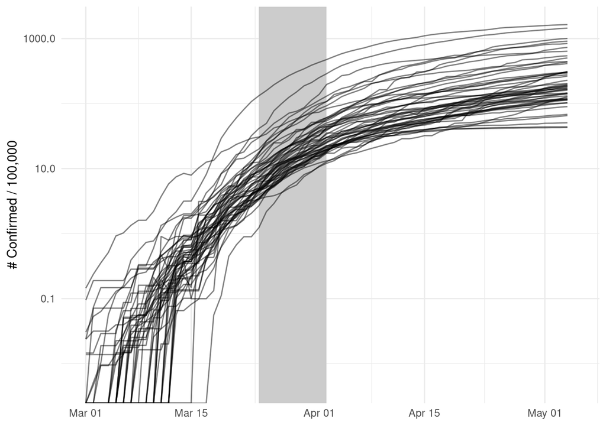

```r
survey_period <- long_data %>% ggplot(aes(x=cdate, y=confirmed_by_100_000,
                                 group=state)) +
  geom_rect(aes(xmin=as.Date("2020-03-24"),
                xmax=as.Date("2020-04-02"),
                ymin=0,
                ymax=Inf
                ), fill="grey80") +
  geom_line(alpha=0.5) +
  scale_x_date(limits = as.Date(c("2020-03-01", "2020-05-05"))) +
  theme_minimal() +
  scale_y_log10(labels = function(x) format(x, scientific = FALSE)) +
  labs(y="# Confirmed / 100,000",
       x=element_blank())
survey_period
```

# Google searches and survey period

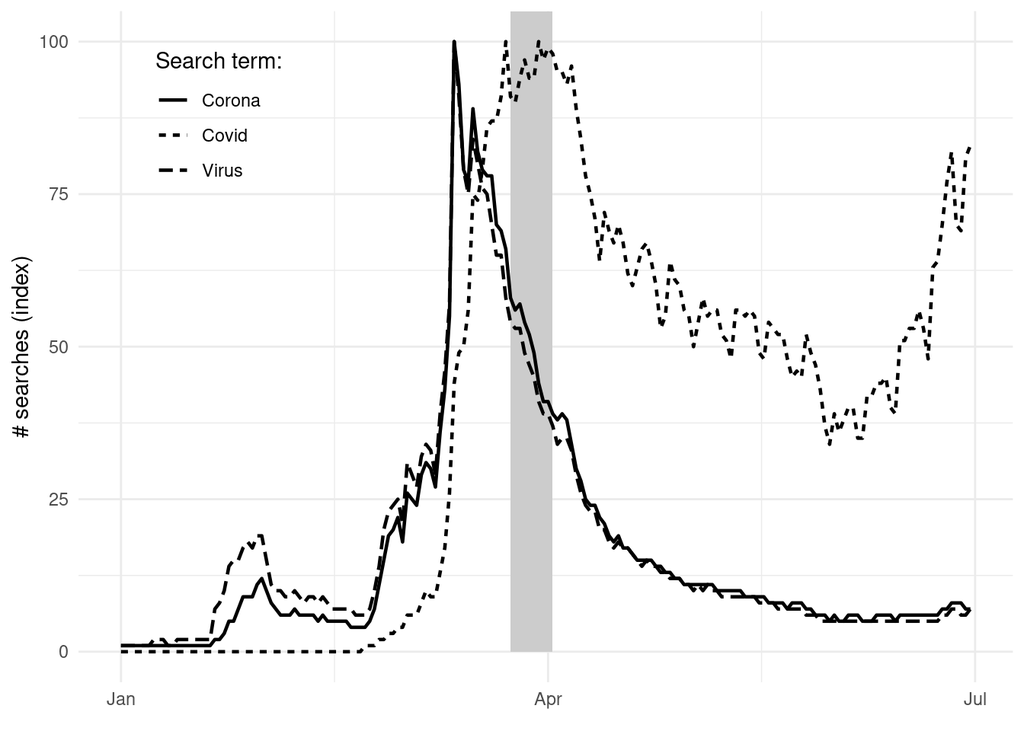

```r
survey_period2 <- google_trends %>%
  ggplot(aes(x=day, y=searches, group=search_term)) +
  geom_rect(aes(xmin=as.Date("2020-03-24"),
                xmax=as.Date("2020-04-02"),
                ymin=0,
                ymax=Inf
                ), fill="grey80") +
  geom_line(aes(linetype=search_term), size=0.8) +
  theme_minimal() +
  labs(y="# searches (index)",
       x=element_blank(),
       linetype="Search term:") +
  theme(legend.position = c(0.15, 0.84))
survey_period2
```

# The data needed for the PAP

The PAP specified that we would use the status per March 26 as reference for how hard each state was hit by the virus, this was based on the idea that the 26th would be the mid point of the survey. Instead the survey was a couple of days delayed, and not March 28 is closer to the mid of the survey.

```r
corona_PAP <- US_covid_outcomes %>%
  filter(cdate == "2020-03-28") %>%
  rename(state = Province_State) %>%
  right_join(population, by="state") %>% filter(!is.na(cdate))
corona_PAP %>% write_csv(here::here("data","corona_status_March-28.csv"))
```

# Correlation between subjective report and confirmed cases

Calculating state averages of the priming question to correlate with level confirmed

```r
primes <- ipsos %>% group_by(state) %>%
  summarize(mean_affected = weighted.mean(prime_affected, Weightvar, na.rm=TRUE),
            mean_estlength = weighted.mean(prime_weeks, Weightvar, na.rm=TRUE)) %>%
  left_join(corona_PAP, by="state") %>%
  mutate(confirmed_by_100_000 = confirmed/pop2019 * 100000)
```

Plotting the self report of how much the local community is affected against actual confirmed rate per March 28.

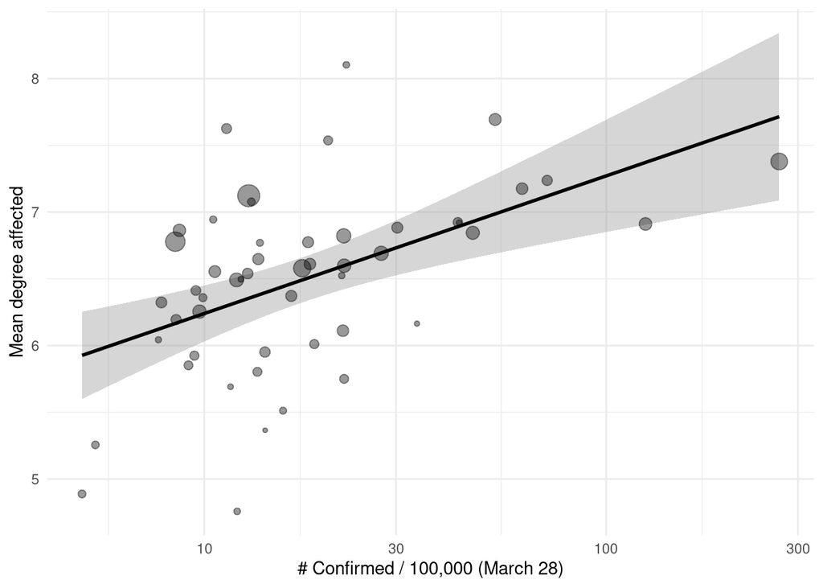

```r
p1 <- primes %>% ggplot(aes(x=confirmed_by_100_000, y=mean_affected)) +
  scale_x_log10() +
  geom_smooth(method='lm', color='black') +
  geom_point(aes(size=pop2019), alpha=0.4) +
  theme_minimal() +
  labs(x="# Confirmed / 100,000 (March 28)",
       y="Mean degree affected") +
  theme(legend.position = "none")
p1
```

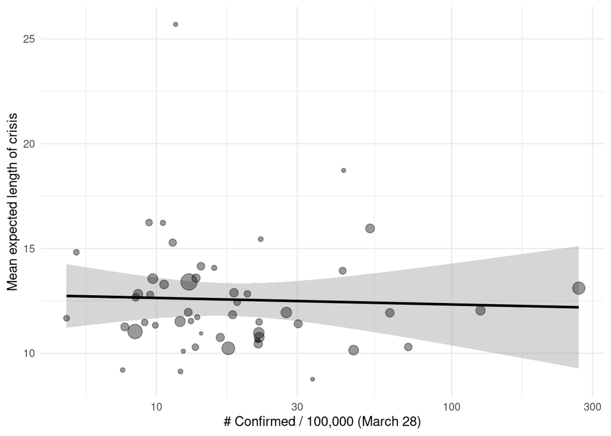

```r
p2 <- primes %>% ggplot(aes(x=confirmed_by_100_000, y=mean_estlength)) +
  scale_x_log10() +
  geom_smooth(method='lm', color='black') +
  geom_point(aes(size=pop2019), alpha=0.4) +
  theme_minimal() +
  labs(x="# Confirmed / 100,000 (March 28)",
       y="Mean expected length of crisis") +
  theme(legend.position = "none")
p2
```

```r
ggsave(here::here("graphs","expected_length_vs_objective.pdf"), width=16, height=10, units="cm")
```

Now a version that combines the Covid-19 data with survey period and the extent to which they are affected.

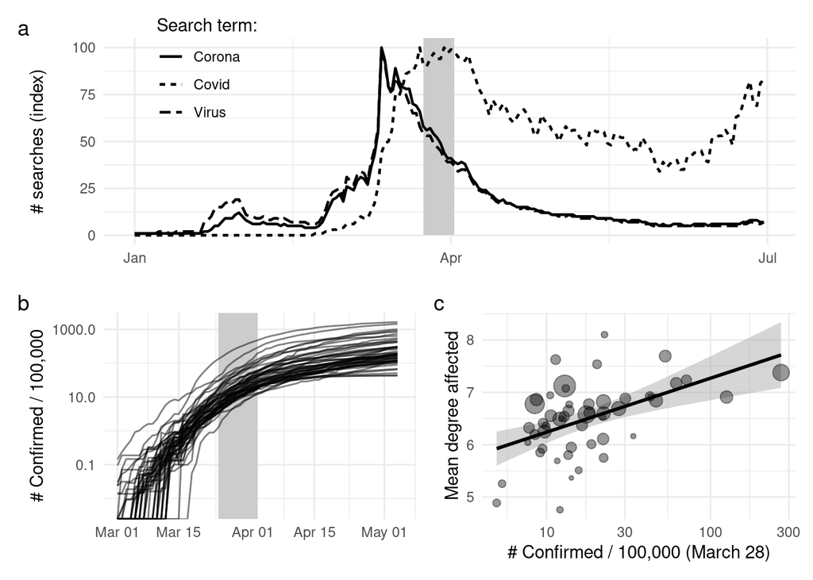

```r
survey_period2 / (survey_period | p1)   + plot_annotation(tag_levels = "a")
```

```r
ggsave(here::here("graphs","survey_period.pdf"), width=16, height=14, units="cm")
```